# U4_1_Limpieza_datos

```r
library(tidyverse)
library(magrittr)
#install.packages("dslabs")
library(dslabs)
```

**#revisemos el dataframe murders**

```r
murders %>% select(state, population, total)
```

| state | population | total |
| --- | --- | --- |
| Alabama | 4779736 | 135 |
| Alaska | 710231 | 19 |
| Arizona | 6392017 | 232 |
| Arkansas | 2915918 | 93 |
| California | 37253956 | 1257 |
| Colorado | 5029196 | 65 |
| Connecticut | 3574097 | 97 |
| Delaware | 897934 | 38 |
| District of Columbia | 601723 | 99 |
| Florida | 19687653 | 669 |

[output cut: 41 more lines]

```r
murders %>% select(state, population, total) %>% head()
```

|  | state | population | total |
| --- | --- | --- | --- |
| 1 | Alabama | 4779736 | 135 |
| 2 | Alaska | 710231 | 19 |
| 3 | Arizona | 6392017 | 232 |
| 4 | Arkansas | 2915918 | 93 |
| 5 | California | 37253956 | 1257 |
| 6 | Colorado | 5029196 | 65 |

**#necesitamos mas información de la tabla (por ejemplo tasa de homicidios por cada 100 mil habitantes)**

```r
murders %>%
  mutate(ratio = total / population * 100000) %>%
  head()
```

|  | state | abb | region | population | total | ratio |
| --- | --- | --- | --- | --- | --- | --- |
| 1 | Alabama | AL | South | 4779736 | 135 | 2.824424 |
| 2 | Alaska | AK | West | 710231 | 19 | 2.675186 |
| 3 | Arizona | AZ | West | 6392017 | 232 | 3.629527 |
| 4 | Arkansas | AR | South | 2915918 | 93 | 3.189390 |
| 5 | California | CA | West | 37253956 | 1257 | 3.374138 |
| 6 | Colorado | CO | West | 5029196 | 65 | 1.292453 |

**#guardar esta tabla con la nueva columna**

```r
murders <- murders %>%
  mutate(ratio = total / population * 100000)
```

**#nos interesa identificar tasas de asesinato de menos de 1 por cada 50 mil personas en una región en específico**

```r
data (murders)
  murders %>%
    mutate(ratio = total / population * 50000) %>%
  filter(ratio < 1 & region == "West")
```

| state | abb | region | population | total | ratio |
| --- | --- | --- | --- | --- | --- |
| Colorado | CO | West | 5029196 | 65 | 0.6462266 |
| Hawaii | HI | West | 1360301 | 7 | 0.2572960 |
| Idaho | ID | West | 1567582 | 12 | 0.3827551 |
| Montana | MT | West | 989415 | 12 | 0.6064189 |
| Oregon | OR | West | 3831074 | 36 | 0.4698421 |
| Utah | UT | West | 2763885 | 22 | 0.3979905 |
| Washington | WA | West | 6724540 | 93 | 0.6914971 |
| Wyoming | WY | West | 563626 | 5 | 0.4435565 |

```r
#solucion
data(murders)
sur_y_oeste <- c("South", "West")
murders <- murders %>%
  mutate(ratio = total/population*50000) %>%
  filter(ratio < 0.9 & region %in% sur_y_oeste) %>%
  select(state, abb, ratio)
murders
```

| state | abb | ratio |
| --- | --- | --- |
| Colorado | CO | 0.6462266 |
| Hawaii | HI | 0.2572960 |
| Idaho | ID | 0.3827551 |
| Montana | MT | 0.6064189 |
| Oregon | OR | 0.4698421 |
| Utah | UT | 0.3979905 |
| Washington | WA | 0.6914971 |
| West Virginia | WV | 0.7285507 |
| Wyoming | WY | 0.4435565 |

**#analisis descriptivo**

```r
data(murders)
summary(murders$total)
```

```
##    Min. 1st Qu.  Median    Mean 3rd Qu.    Max.
##     2.0    24.5    97.0   184.4   268.0  1257.0
```

```r
murders %>% group_by(region) %>%
  summarise (m.total=mean(total))
```

| region | m.total |
| --- | --- |
| Northeast | 163.2222 |
| South | 246.7647 |
| North Central | 152.3333 |
| West | 147.0000 |

EJERCICIO **#revisemos el df de la clase pasada**

```r
U3_2<- read_csv("../data/U3_2.csv")
U3_2
```

| TAR | ARF | CO | GA | Etapas |
| --- | --- | --- | --- | --- |
| 5.1 | 3.5 | 1.4 | 0.2 | Etapa1 |
| 4.9 | 3.0 | 1.4 | 0.2 | Etapa1 |
| 4.7 | 3.2 | 1.3 | 0.2 | Etapa1 |
| 4.6 | 3.1 | 1.5 | 0.2 | Etapa1 |
| 5.0 | 3.6 | 1.4 | 0.2 | Etapa1 |
| 5.4 | 3.9 | 1.7 | 0.4 | Etapa1 |
| 4.6 | 3.4 | 1.4 | 0.3 | Etapa1 |
| 5.0 | 3.4 | 1.5 | 0.2 | Etapa1 |
| 4.4 | 2.9 | 1.4 | 0.2 | Etapa1 |
| 4.9 | 3.1 | 1.5 | 0.1 | Etapa1 |

[output cut: 140 more lines]

```r
U4_1 <-gather(data = U3_2, genes, conteo, TAR, ARF, CO, GA, -Etapas)
head(U4_1)
```

| Etapas | genes | conteo |
| --- | --- | --- |
| Etapa1 | TAR | 5.1 |
| Etapa1 | TAR | 4.9 |
| Etapa1 | TAR | 4.7 |
| Etapa1 | TAR | 4.6 |
| Etapa1 | TAR | 5.0 |
| Etapa1 | TAR | 5.4 |

```r
tail(U4_1)
```

| Etapas | genes | conteo |
| --- | --- | --- |
| Etapa3 | GA | 2.5 |
| Etapa3 | GA | 2.3 |
| Etapa3 | GA | 1.9 |
| Etapa3 | GA | 2.0 |
| Etapa3 | GA | 2.3 |
| Etapa3 | GA | 1.8 |

```r
x <- gather(data = U3_2, genes, conteo, TAR, ARF, CO, GA, -Etapas)
head(x)
```

| Etapas | genes | conteo |
| --- | --- | --- |
| Etapa1 | TAR | 5.1 |
| Etapa1 | TAR | 4.9 |
| Etapa1 | TAR | 4.7 |
| Etapa1 | TAR | 4.6 |
| Etapa1 | TAR | 5.0 |
| Etapa1 | TAR | 5.4 |

```r
tail(x)
```

| Etapas | genes | conteo |
| --- | --- | --- |
| Etapa3 | GA | 2.5 |
| Etapa3 | GA | 2.3 |
| Etapa3 | GA | 1.9 |
| Etapa3 | GA | 2.0 |
| Etapa3 | GA | 2.3 |
| Etapa3 | GA | 1.8 |

```r
view(x)
summary(x)
```

```
##     Etapas             genes               conteo
##  Length:600         Length:600         Min.   :0.100
##  Class :character   Class :character   1st Qu.:1.700
##  Mode  :character   Mode  :character   Median :3.200
##                                        Mean   :3.465
##                                        3rd Qu.:5.100
##                                        Max.   :7.900
```

#desviación estándar

```r
sd(U4_1$conteo)
```

```
## [1] 1.97549
```

```r
dim(U4_1)
```

```
## [1] 600   3
```

**#revisemos únicamente los datos de los genes TAR y CO**

```r
a<- filter(x, genes == "TAR" | genes == "CO")
a
```

| Etapas | genes | conteo |
| --- | --- | --- |
| Etapa1 | TAR | 5.1 |
| Etapa1 | TAR | 4.9 |
| Etapa1 | TAR | 4.7 |
| Etapa1 | TAR | 4.6 |
| Etapa1 | TAR | 5.0 |
| Etapa1 | TAR | 5.4 |
| Etapa1 | TAR | 4.6 |
| Etapa1 | TAR | 5.0 |
| Etapa1 | TAR | 4.4 |
| Etapa1 | TAR | 4.9 |

[output cut: 290 more lines]

**#y si hacemos una gráfica?**

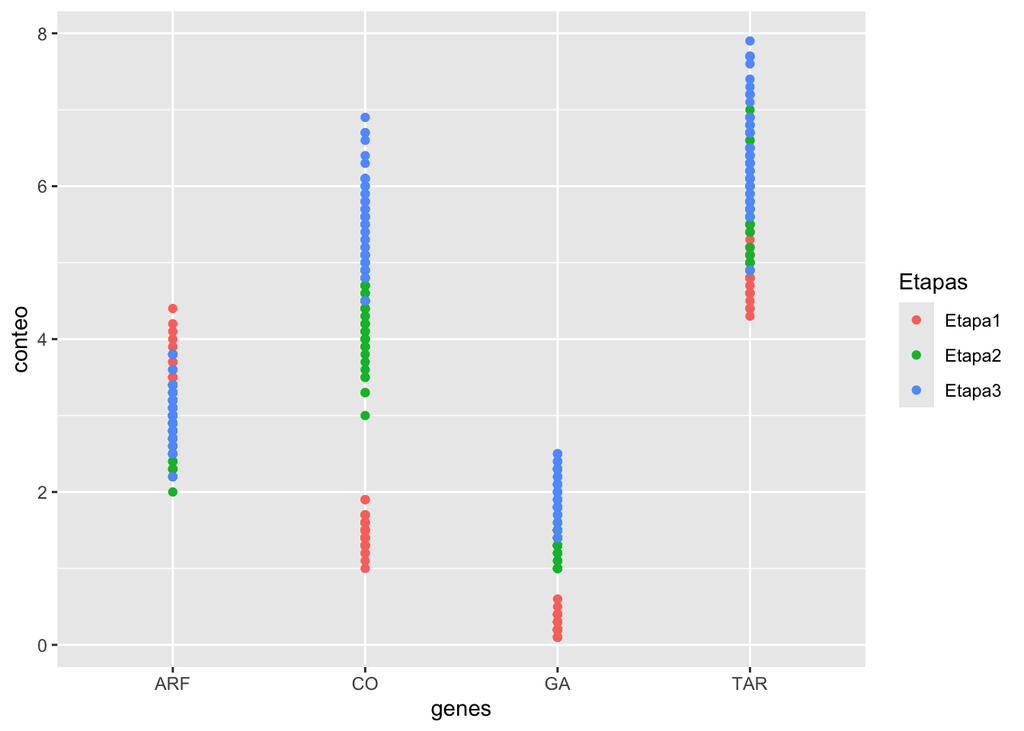

```r
ggplot(data = x, mapping = aes(x = genes, y = conteo, colour = Etapas)) +
  geom_point()
```

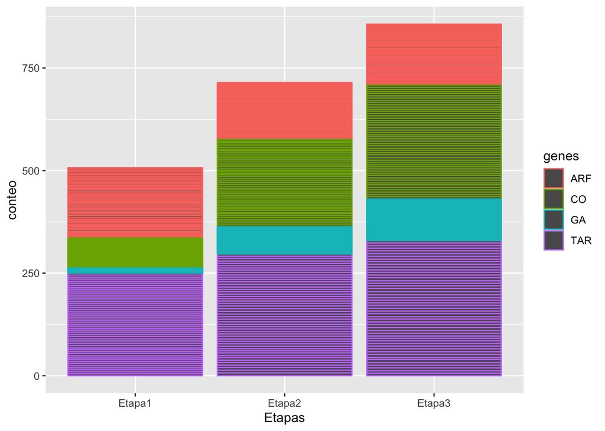

```r
ggplot(data = x, mapping = aes(x = Etapas, y = conteo, colour = genes)) +
  geom_col()
```

**#Prueba t, acomodamos el df para tener solo 2 etapas

```r
y <- U3_2 %>% filter(Etapas == c("Etapa3","Etapa2"))
t.test (ARF~Etapas, data = y)
```

```
##
##  Welch Two Sample t-test
##
## data:  ARF by Etapas
## t = -2.0819, df = 47.944, p-value = 0.04271
## alternative hypothesis: true difference in means between group Etapa2 and group Etapa3 is not equal to 0
## 95 percent confidence interval:
##  -0.338114763 -0.005885237
## sample estimates:
## mean in group Etapa2 mean in group Etapa3
##                2.764                2.936
```

**#Prueba de T

```r
ChickWeight
```

|  | weight | Time | Chick | Diet |
| --- | --- | --- | --- | --- |
| 1 | 42 | 0 | 1 | 1 |
| 2 | 51 | 2 | 1 | 1 |
| 3 | 59 | 4 | 1 | 1 |
| 4 | 64 | 6 | 1 | 1 |
| 5 | 76 | 8 | 1 | 1 |
| 6 | 93 | 10 | 1 | 1 |
| 7 | 106 | 12 | 1 | 1 |
| 8 | 125 | 14 | 1 | 1 |
| 9 | 149 | 16 | 1 | 1 |
| 10 | 171 | 18 | 1 | 1 |

[output cut: 568 more lines]

```r
str(ChickWeight)
```

```
## Classes 'nfnGroupedData', 'nfGroupedData', 'groupedData' and 'data.frame':   578 obs. of  4 variables:
##  $ weight: num  42 51 59 64 76 93 106 125 149 171 ...
##  $ Time  : num  0 2 4 6 8 10 12 14 16 18 ...
##  $ Chick : Ord.factor w/ 50 levels "18"<"16"<"15"<..: 15 15 15 15 15 15 15 15 15 15 ...
##  $ Diet  : Factor w/ 4 levels "1","2","3","4": 1 1 1 1 1 1 1 1 1 1 ...
##  - attr(*, "formula")=Class 'formula'  language weight ~ Time | Chick
##   .. ..- attr(*, ".Environment")=<environment: R_EmptyEnv>
##  - attr(*, "outer")=Class 'formula'  language ~Diet
##   .. ..- attr(*, ".Environment")=<environment: R_EmptyEnv>
##  - attr(*, "labels")=List of 2
##   ..$ x: chr "Time"
##   ..$ y: chr "Body weight"
##  - attr(*, "units")=List of 2
##   ..$ x: chr "(days)"
##   ..$ y: chr "(gm)"
```

```r
ChickW<- ChickWeight %>% filter(ChickWeight$Diet == c("1","2"))
t.test(weight~Diet, data = ChickW)
```

```
##
##  Welch Two Sample t-test
##
## data:  weight by Diet
## t = -2.5871, df = 97.031, p-value = 0.01116
## alternative hypothesis: true difference in means between group 1 and group 2 is not equal to 0
## 95 percent confidence interval:
##  -49.849622  -6.568559
## sample estimates:
## mean in group 1 mean in group 2
##        101.3909        129.6000
```

**#Prueba de Wilcoxon (Mann Whitney)

```r
Hombres = c(19, 22, 16, 29, 24)
Mujeres = c(20, 11, 17, 12)
wilcox.test(Hombres, Mujeres)
```

```
##
##  Wilcoxon rank sum exact test
##
## data:  Hombres and Mujeres
## W = 17, p-value = 0.1111
## alternative hypothesis: true location shift is not equal to 0
```

**#El valor de pvalue es mayor a 0.05, por lo que no se rechaza la H0 nula

**# Prueba de ANOVA**

```r
aov(weight~Diet+Time,ChickW)
```

```
## Call:
##    aov(formula = weight ~ Diet + Time, data = ChickW)
##
## Terms:
##                     Diet     Time Residuals
## Sum of Squares   30893.9 420682.9  241867.7
## Deg. of Freedom        1        1       167
##
## Residual standard error: 38.05666
## Estimated effects may be unbalanced
```

```r
aov(weight~Diet*Time,ChickW)
```

```
## Call:
##    aov(formula = weight ~ Diet * Time, data = ChickW)
##
## Terms:
##                     Diet     Time Diet:Time Residuals
## Sum of Squares   30893.9 420682.9    8091.8  233775.9
## Deg. of Freedom        1        1         1       166
##
## Residual standard error: 37.52717
## Estimated effects may be unbalanced
```

```r
aov.demo<-aov(weight~Diet*Time,ChickW)
summary(aov.demo)
```

```
##              Df Sum Sq Mean Sq F value   Pr(>F)
## Diet          1  30894   30894  21.937 5.83e-06 ***
## Time          1 420683  420683 298.719  < 2e-16 ***
## Diet:Time     1   8092    8092   5.746   0.0176 *
## Residuals   166 233776    1408
## ---
## Signif. codes:  0 '***' 0.001 '**' 0.01 '*' 0.05 '.' 0.1 ' ' 1
```

**#Prueba de Tukey

```r
aov.demo<-aov(weight~Diet*as.factor(Time),ChickW)
TukeyHSD(aov.demo)
```

```
##   Tukey multiple comparisons of means
##     95% family-wise confidence level
##
## Fit: aov(formula = weight ~ Diet * as.factor(Time), data = ChickW)
##
## $Diet
##         diff     lwr      upr    p adj
## 2-1 28.20909 15.9731 40.44508 1.07e-05
##
## $`as.factor(Time)`
##              diff        lwr       upr     p adj
## 2-0    -8.1994949 -55.941359  39.54237 0.9999893
## 4-0    15.2196970 -38.254291  68.69368 0.9985041
## 6-0    14.3005051 -33.441359  62.04237 0.9976302
## 8-0    38.5833333 -14.890654  92.05732 0.4157314
## 10-0   43.0782828  -4.663581  90.82015 0.1201538
## 12-0   71.3106061  17.836618 124.78459 0.0010712
## 14-0   74.2838681  25.983601 122.58414 0.0000612
## 16-0  106.1287879  52.654800 159.60278 0.0000000
## 18-0  115.1401515  66.219299 164.06100 0.0000000
## 20-0  135.9469697  82.472982 189.42096 0.0000000
## 21-0  135.3901515  86.469299 184.31100 0.0000000
## 4-2    23.4191919 -25.607436  72.44582 0.9117060
## 6-2    22.5000000 -20.201621  65.20162 0.8420694
## 8-2    46.7828283  -2.243800  95.80946 0.0766418
## 10-2   51.2777778   8.576157  93.97940 0.0056797
## 12-2   79.5101010  30.483473 128.53673 0.0000173
## 14-2   82.4833630  39.158327 125.80840 0.0000002
## 16-2  114.3282828  65.301655 163.35491 0.0000000
## 18-2  123.3396465  79.323823 167.35547 0.0000000
## 20-2  144.1464646  95.119837 193.17309 0.0000000
## 21-2  143.5896465  99.573823 187.60547 0.0000000
## 6-4    -0.9191919 -49.945820  48.10744 1.0000000
## 8-4    23.3636364 -31.260461  77.98773 0.9579000
## 10-4   27.8585859 -21.168042  76.88521 0.7657745
## 12-4   56.0909091   1.466812 110.71501 0.0384248
## 14-4   59.0641711   9.493610 108.63473 0.0063451
## 16-4   90.9090909  36.284993 145.53319 0.0000090
## 18-4   99.9204545  49.745017 150.09589 0.0000000
## 20-4  120.7272727  66.103175 175.35137 0.0000000
```

[output cut: 301 more lines]

```
## 2:18-1:18  36.033333  -37.8070733 109.87374 0.9798830
## 1:20-1:18  25.696970  -46.8738797  98.26782 0.9997650
## 2:20-1:18         NA           NA        NA        NA
## 1:21-1:18   9.000000  -73.5560843  91.55608 1.0000000
## 2:21-1:18  63.033333  -10.8070733 136.87374 0.2167278
## 1:20-2:18 -10.336364  -72.8137737  52.14105 1.0000000
## 2:20-2:18         NA           NA        NA        NA
## 1:21-2:18 -27.033333 -100.8737399  46.80707 0.9996016
## 2:21-2:18  27.000000  -36.9476679  90.94767 0.9967585
## 2:20-1:20         NA           NA        NA        NA
## 1:21-1:20 -16.696970  -89.2678191  55.87388 0.9999999
## 2:21-1:20  37.336364  -25.1410464  99.81377 0.8565998
## 1:21-2:20         NA           NA        NA        NA
## 2:21-2:20         NA           NA        NA        NA
## 2:21-1:21  54.033333  -19.8070733 127.87374 0.5124762
```

**Test de Friedman (valoracion de degustacion de un vino de acuerdo a la hora)

```r
valoracion <- c( 9, 5, 2, 6, 3, 1, 5, 5, 5, 11, 5, 1, 8, 4, 3, 10, 4, 1, 7, 3, 4 )
hora <- factor( rep( c( "mañana", "tarde", "noche" ), 7 ) )
sujeto <- factor( rep( 1:7, each = 3 ) )
datos <- data.frame( valoracion, hora, sujeto )
head(datos)
```

|  | valoracion | hora | sujeto |
| --- | --- | --- | --- |
| 1 | 9 | mañana | 1 |
| 2 | 5 | tarde | 1 |
| 3 | 2 | noche | 1 |
| 4 | 6 | mañana | 2 |
| 5 | 3 | tarde | 2 |
| 6 | 1 | noche | 2 |

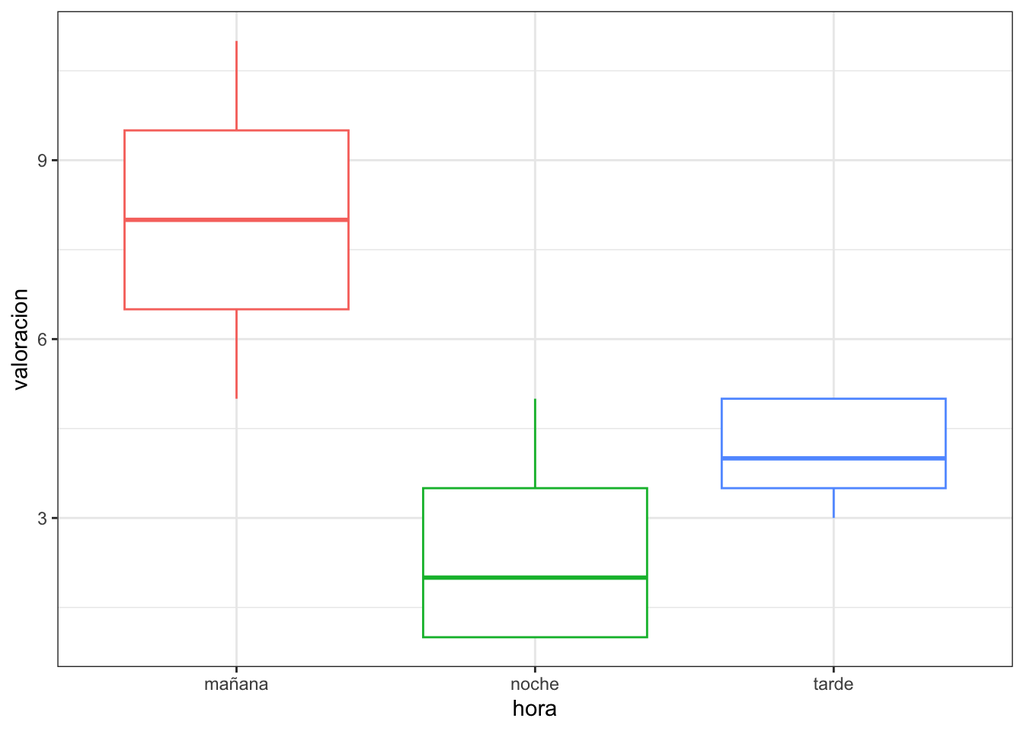

```r
#grafiquemos
library(ggplot2)
ggplot(data = datos, mapping = aes(x = hora, y = valoracion, colour = hora)) +
    geom_boxplot() +
    theme_bw() +
    theme(legend.position = "none")
```

```r
friedman.test(valoracion, hora, sujeto)
```

```
##
##  Friedman rank sum test
##
## data:  valoracion, hora and sujeto
## Friedman chi-squared = 10.333, df = 2, p-value = 0.005704
```

**#Prueba de Chi cuadrada (ejemplo de encuesta de opinion sobre aborto)

```r
M <- as.table(rbind(c(762, 468), c(484, 477)))
# Damos nombre a las columnas y las filas
colnames(M) <- c("A favor","En contra")
rownames(M) <- c("Mujeres","Hombres")
M
```

```
##         A favor En contra
## Mujeres     762       468
## Hombres     484       477
```

```r
chisq.test(M)
```

```
##
##  Pearson's Chi-squared test with Yates' continuity correction
##
## data:  M
## X-squared = 29.06, df = 1, p-value = 7.019e-08
```

```r
data(murders)##data me va a leer el dataframe
murders ## a ver si es cierto, debería de abrir la tabla (revisa tu Global Environment)
```

| state | abb | region | population | total |
| --- | --- | --- | --- | --- |
| Alabama | AL | South | 4779736 | 135 |
| Alaska | AK | West | 710231 | 19 |
| Arizona | AZ | West | 6392017 | 232 |
| Arkansas | AR | South | 2915918 | 93 |
| California | CA | West | 37253956 | 1257 |
| Colorado | CO | West | 5029196 | 65 |
| Connecticut | CT | Northeast | 3574097 | 97 |
| Delaware | DE | South | 897934 | 38 |
| District of Columbia | DC | South | 601723 | 99 |
| Florida | FL | South | 19687653 | 669 |

[output cut: 41 more lines]

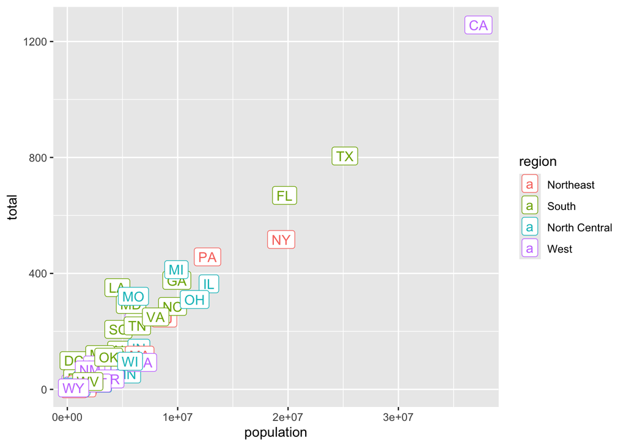

```r
#Vamos a graficar estos valores para ver si hay alguna tendencia
murders %>% ggplot(aes(population, total,label= abb, color = region)) +
  geom_label()
```